# Practical Machine Learning Project

### Overview

In this report, motion dataset which is related five different type of exercise in to R program, and a prediction model will be build based on the sub divided training set. The training data contains following key variables with components:

- Accelration: x, y and z
- Gyro: x, y and z
- Magnet: x, y and z
- Tilt: yaw, pitch and roll

Additionally, total and var of variables are found in different columns.

### Setup

Before starting analysis, those libraries are included in R. The main library is caret, and additional moudules are included to explore the dataset. I would like to note that parallel processing has been registered for 4 cores of the CPU. This optional configuration is mainly used in train() function in order to speed up the step.

```r
library(caret)
library(AppliedPredictiveModeling)
library(rattle)
```

```r
library(ggplot2)
library(gridExtra)
library(doParallel)
registerDoParallel(core=4)
```

Two files will be downloaded and they will be loaded into memory.

```r
if (!file.exists("pml-training.csv")){
  download.file("https://d396qusza40orc.cloudfront.net/predmachlearn/pml-training.csv", destfile = "pml-training.csv", method="curl")
}
if (!file.exists("pml-testing.csv")){
  download.file("https://d396qusza40orc.cloudfront.net/predmachlearn/pml-testing.csv", destfile = "pml-testing.csv", method="curl")
}
training_src<-read.csv("pml-training.csv")
testing_final<-read.csv("pml-testing.csv")
```

### Exploratory Data Analysis

To begin with this dataset, I would like to extract sample subset by the person. Pedro was specified as an example. The first figure simply render different exercises for gyro_arm_y component based on the timeline. The rest of three figures are few combinations of variables: x v.s. y of accelerometer values (top-right), magnet v.s. gyros of the same x component (bottom-left), and pitch v.s. roll of the arm (bottom-right).

By looking over those graphs, each exercises are not clearly separated; however, some segments could be visually identified. For example, the bottom-right figure, pitch v.s. roll, presents the exercise type A (red) spreads all over the area while the exercise type D (blue) values gather from the center to positive areas in terms of the roll axis.

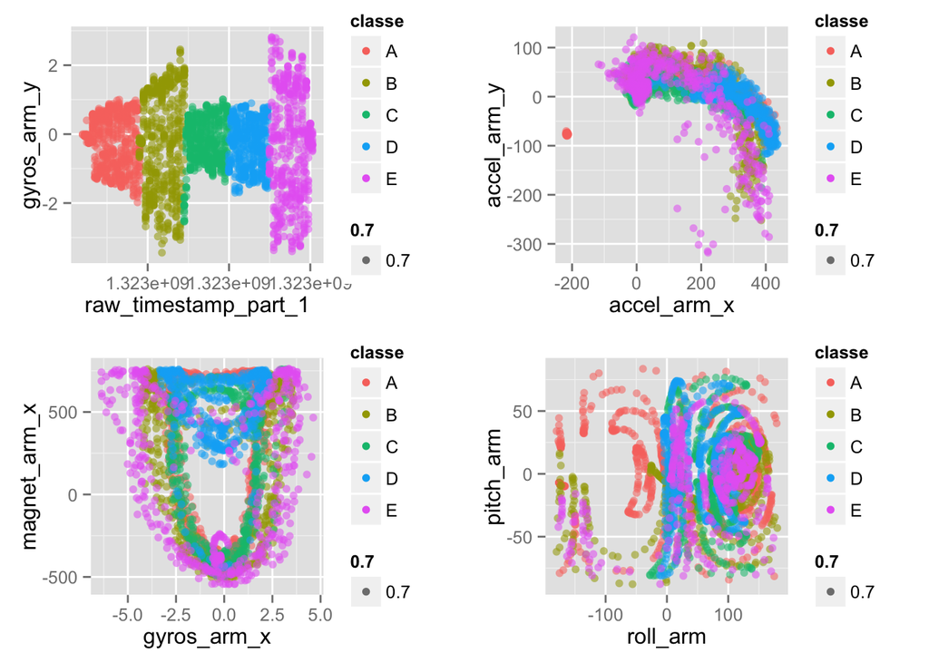

```r
tmp<-training_src[training_src$user_name=='pedro',]
g1<-qplot(raw_timestamp_part_1, gyros_arm_y,col=classe,alpha=0.7,data=tmp)
g2<-qplot(accel_arm_x,accel_arm_y,col=classe,alpha=0.7,data=tmp)
g3<-qplot(gyros_arm_x,magnet_arm_x,col=classe,alpha=0.7,data=tmp)
g4<-qplot(roll_arm,pitch_arm,col=classe,alpha=0.7,data=tmp)
grid.arrange(g1,g2,g3,g4, ncol=2,nrow=2)
```

You might notice some outliers in the accelerometer value of the exercise type A.

### Partitioning

With caret’s createDataPartition function, the training and testing sets are splited into 70% and 30% ratio. Note that the classe variable was targetd for this partitioning process.

```r
inTrain = createDataPartition(training_src$classe, p = 0.7, list=F)
training = training_src[inTrain,]
testing = training_src[-inTrain,]
```

Key variables are selected with grep function. As result of this selection process, only 52 predictors are extracted out of 160 variables. By adding the outcome, the total number of columns is 53.

```r
cols<-grep("^pitch|^yaw|^roll|^gyros|^accel|^magnet|^total|^classe",names(training))
length(cols)
```

```
## [1] 53
```

### Training

In this training section, I would like to start with “rpart” which is simple classification tree building, and then the “rf” method will be applied in the next approach with PCA. Since the nature of he dataset is not quite dedicated by the outcome, I expect this might generate lower accuracy than the next approach. In both steps, the default bootstrap option are used for the train control.

#### Approach 1: rpart

Train the model only selected columns. See the final model below.

```r
fit <- train(classe ~.,method="rpart",data=training[,cols])
fit$finalModel
```

```
## n= 13737
##
## node), split, n, loss, yval, (yprob)
##       * denotes terminal node
##
##  1) root 13737 9831 A (0.28 0.19 0.17 0.16 0.18)
##    2) roll_belt< 130.5 12571 8675 A (0.31 0.21 0.19 0.18 0.11)
##      4) pitch_forearm< -33.95 1105    7 A (0.99 0.0063 0 0 0) *
##      5) pitch_forearm>=-33.95 11466 8668 A (0.24 0.23 0.21 0.2 0.12)
##       10) magnet_dumbbell_y< 439.5 9692 6954 A (0.28 0.18 0.24 0.19 0.11)
##         20) roll_forearm< 124.5 6012 3569 A (0.41 0.18 0.18 0.17 0.061) *
##         21) roll_forearm>=124.5 3680 2465 C (0.08 0.18 0.33 0.23 0.18) *
##       11) magnet_dumbbell_y>=439.5 1774  884 B (0.034 0.5 0.046 0.23 0.19) *
##    3) roll_belt>=130.5 1166   10 E (0.0086 0 0 0 0.99) *
```

Here is the visualized tree structure.

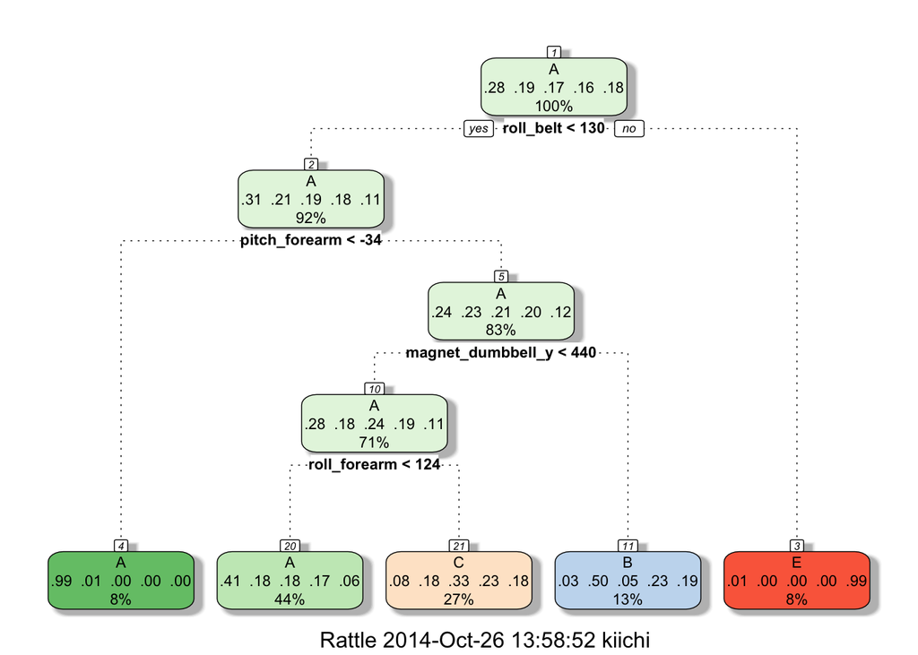

```r
fancyRpartPlot(fit$finalModel)
```

Using the partitioned testing set, the accuracy is displayed below.

```r
est<-predict(fit,testing)
confusionMatrix(testing$classe,est)
```

```
## Confusion Matrix and Statistics
##
##           Reference
## Prediction    A    B    C    D    E
##          A 1543   21  106    0    4
##          B  483  396  260    0    0
##          C  493   27  506    0    0
##          D  456  160  348    0    0
##          E  157  151  299    0  475
##
## Overall Statistics
##
##                Accuracy : 0.496
##                  95% CI : (0.483, 0.509)
##     No Information Rate : 0.532
##     P-Value [Acc > NIR] : 1
##
##                   Kappa : 0.34
##  Mcnemar's Test P-Value : NA
##
## Statistics by Class:
##
##                      Class: A Class: B Class: C Class: D Class: E
## Sensitivity             0.493   0.5245    0.333       NA   0.9916
## Specificity             0.952   0.8552    0.881    0.836   0.8877
## Pos Pred Value          0.922   0.3477    0.493       NA   0.4390
## Neg Pred Value          0.623   0.9244    0.792       NA   0.9992
## Prevalence              0.532   0.1283    0.258    0.000   0.0814
## Detection Rate          0.262   0.0673    0.086    0.000   0.0807
## Detection Prevalence    0.284   0.1935    0.174    0.164   0.1839
## Balanced Accuracy       0.723   0.6898    0.607       NA   0.9397
```

#### Approach 2: rf with pca

Random Forest (rf) option will be selected as the method. PCA is applied for preprocessing the data. Note that the pca option will also do scaling and centering. Also, see the final model below.

```r
fit<-train(classe~.,method="rf",data=training[,cols],preProcess=c("pca"))
fit$finalModel
```

```
##
## Call:
##  randomForest(x = x, y = y, mtry = param$mtry)
##                Type of random forest: classification
##                      Number of trees: 500
## No. of variables tried at each split: 2
##
##         OOB estimate of  error rate: 2.59%
## Confusion matrix:
##      A    B    C    D    E class.error
## A 3868   16   15    5    2    0.009729
## B   52 2559   40    0    7    0.037246
## C    4   37 2329   22    4    0.027963
## D    6    1   93 2146    6    0.047069
## E    1   12   18   15 2479    0.018218
```

Using the partitioned testing set, the accuracy is displayed below.

```r
est<-predict(fit,testing)
confusionMatrix(testing$classe,est)
```

```
## Confusion Matrix and Statistics
##
##           Reference
## Prediction    A    B    C    D    E
##          A 1661    3    8    1    1
##          B   21 1107   10    0    1
##          C    1   11 1004   10    0
##          D    0    1   43  919    1
##          E    1    4    3    9 1065
##
## Overall Statistics
##
##                Accuracy : 0.978
##                  95% CI : (0.974, 0.982)
##     No Information Rate : 0.286
##     P-Value [Acc > NIR] : < 2e-16
##
##                   Kappa : 0.972
##  Mcnemar's Test P-Value : 8.32e-08
##
## Statistics by Class:
##
##                      Class: A Class: B Class: C Class: D Class: E
## Sensitivity             0.986    0.983    0.940    0.979    0.997
## Specificity             0.997    0.993    0.995    0.991    0.996
## Pos Pred Value          0.992    0.972    0.979    0.953    0.984
## Neg Pred Value          0.995    0.996    0.987    0.996    0.999
## Prevalence              0.286    0.191    0.181    0.160    0.181
## Detection Rate          0.282    0.188    0.171    0.156    0.181
## Detection Prevalence    0.284    0.194    0.174    0.164    0.184
## Balanced Accuracy       0.992    0.988    0.968    0.985    0.997
```

### Final Assessment

Using given testing dataset that contains 20 rows, the model has been applied on them. The final classification results are shown below.

```r
est<-predict(fit,testing_final[,cols])
est
```

```
##  [1] B A A A A E D B A A B C B A E E A B B B
## Levels: A B C D E
```

### Reference

Human Activity Recognition Project (http://groupware.les.inf.puc-rio.br/har)